# Lab-3.1: Ridge and lasso regularization

Author: Dr. Purna Gamage

**Instructions**

- Read and complete all exercises below in the provided `.rmd` notebook
- click here to download the notebook for the assignment

**Submission:**

- You need to upload ONE document to Canvas when you are done.
- A PDF (or HTML) of the completed form of this notebook
- The final uploaded version should NOT have any code-errors present.
- All outputs must be visible in the uploaded version, including code-cell outputs, images, graphs, etc

## Import

```r
require(ISLR)
require(MASS)
require(glmnet)
require(leaps)
require(tidyverse)
set.seed(3315)
```

## Question-1:

In this exercise, we will predict the number of applications received using the other variables in the College data set.

Source: ISLR ch. 6 #9abcd

```r
# LOOK AT DATA
data(College)
print(class(College))
```

```
[1] "data.frame"
```

```r
print(dim(College))
```

```
[1] 777  18
```

```r
print(head(College))
```

```
                             Private Apps Accept Enroll Top10perc Top25perc
Abilene Christian University     Yes 1660   1232    721        23        52
Adelphi University               Yes 2186   1924    512        16        29
Adrian College                   Yes 1428   1097    336        22        50
Agnes Scott College              Yes  417    349    137        60        89
Alaska Pacific University        Yes  193    146     55        16        44
Albertson College                Yes  587    479    158        38        62
                             F.Undergrad P.Undergrad Outstate Room.Board Books
Abilene Christian University        2885         537     7440       3300   450
Adelphi University                  2683        1227    12280       6450   750
Adrian College                      1036          99    11250       3750   400
Agnes Scott College                  510          63    12960       5450   450
Alaska Pacific University            249         869     7560       4120   800
Albertson College                    678          41    13500       3335   500
                             Personal PhD Terminal S.F.Ratio perc.alumni Expend
Abilene Christian University     2200  70       78      18.1          12   7041
Adelphi University               1500  29       30      12.2          16  10527
Adrian College                   1165  53       66      12.9          30   8735
Agnes Scott College               875  92       97       7.7          37  19016
Alaska Pacific University        1500  76       72      11.9           2  10922
Albertson College                 675  67       73       9.4          11   9727
                             Grad.Rate
Abilene Christian University        60
Adelphi University                  56
Adrian College                      54
Agnes Scott College                 59
Alaska Pacific University           15
Albertson College                   55
```

### Q1.a:

Split the data set into a training set and a test set.

```r
## Convert Private into a binary column
College$Private <- ifelse(College$Private == "Yes",1,0)
indexes <- sample(1:nrow(College), floor(nrow(College)*.8))
train <- College[indexes,]
test <- College[!1:nrow(College) %in% indexes,]
```

### Q1.b:

Fit a linear model using least squares on the training set, and print the test error obtained.

```r
model <- lm(Apps ~., data = train)
pred <- predict(model, test)
RMSE <- sqrt(mean((test$Apps - pred)**2))
summary(model)
```

```
Call:
lm(formula = Apps ~ ., data = train)

Residuals:
    Min      1Q  Median      3Q     Max
-2966.1  -443.1   -41.1   317.9  6895.8

Coefficients:
              Estimate Std. Error t value Pr(>|t|)
(Intercept) -7.013e+02  4.451e+02  -1.576 0.115657
Private     -5.381e+02  1.504e+02  -3.577 0.000375 ***
Accept       1.275e+00  5.806e-02  21.956  < 2e-16 ***
Enroll      -3.775e-02  2.256e-01  -0.167 0.867197
Top10perc    4.875e+01  5.895e+00   8.270 8.58e-16 ***
Top25perc   -1.513e+01  4.845e+00  -3.122 0.001883 **
F.Undergrad  3.063e-02  4.029e-02   0.760 0.447465
P.Undergrad  4.226e-02  3.446e-02   1.226 0.220561
Outstate    -6.196e-02  2.100e-02  -2.951 0.003292 **
Room.Board   1.752e-01  5.217e-02   3.359 0.000832 ***
Books        1.506e-01  2.794e-01   0.539 0.589976
Personal    -9.783e-03  7.044e-02  -0.139 0.889581
PhD         -7.393e+00  4.924e+00  -1.501 0.133757
Terminal    -3.843e+00  5.478e+00  -0.702 0.483252
S.F.Ratio    1.208e+01  1.388e+01   0.870 0.384808
perc.alumni -5.899e+00  4.479e+00  -1.317 0.188386
Expend       7.663e-02  1.260e-02   6.082 2.10e-09 ***
Grad.Rate    1.163e+01  3.212e+00   3.620 0.000319 ***
---
Signif. codes:  0 '***' 0.001 '**' 0.01 '*' 0.05 '.' 0.1 ' ' 1

Residual standard error: 1018 on 603 degrees of freedom
Multiple R-squared:  0.9181,    Adjusted R-squared:  0.9158
F-statistic: 397.7 on 17 and 603 DF,  p-value: < 2.2e-16
```

```r
cat(paste0("Test RMSE: ", RMSE, "\n"))
```

```
Test RMSE: 1307.24572485468
```

With the standard regression we see a whole host of insignificant variables.

### Q1.c:

- Fit a ridge regression model on the training set, with $\lambda$ chosen by cross-validation.
- Plot the test MSE as a function of the log of the regularization parameter (i.e. log($\lambda$)) for several orders of magnitude.
- Also report the test error obtained.

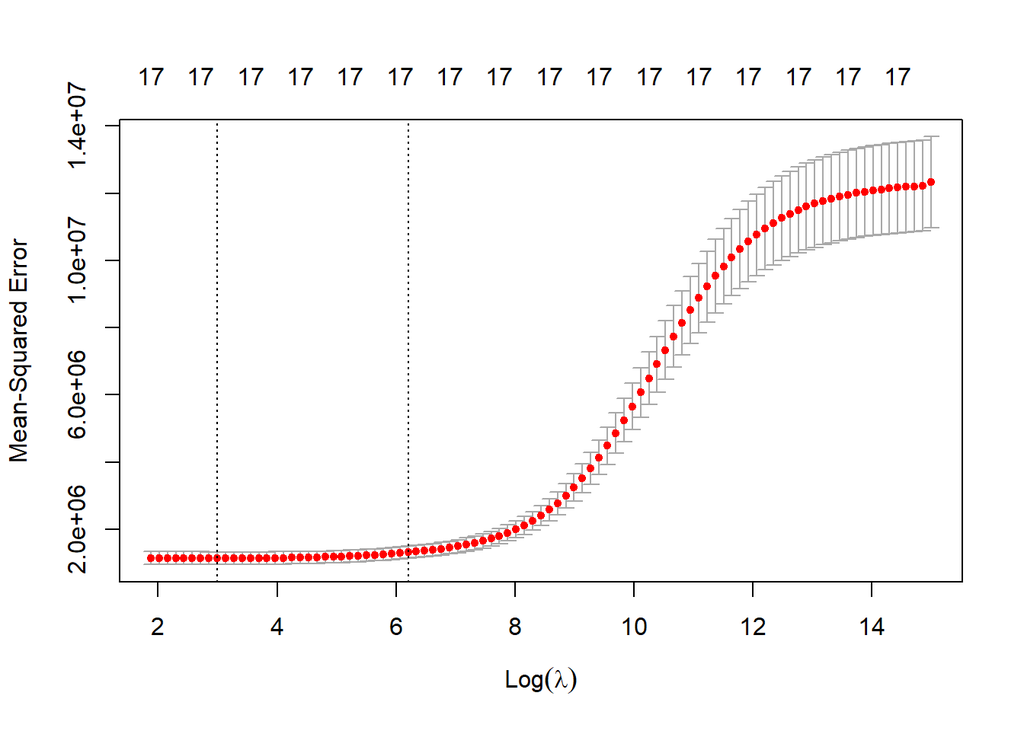

```r
# Separate data from target
X_train <- as.matrix(train %>% select(!Apps))
y_train <- train$Apps
X_test <- as.matrix(test %>% select(!Apps))
y_test <- test$Apps

# Fit ridge regression model with 10-fold cross-validation
cv_model <- cv.glmnet(X_train, y_train, alpha=0, nfolds=10, lambda.min.ratio = .000001)

# Plot test MSE vs. log(lambda)
plot(cv_model)
```

```r
# Report test error
test_preds <- predict(cv_model, newx=X_test, s='lambda.min')
test_rmse <- sqrt(mean((test_preds - y_test)^2))
cat(paste0("Test RMSE: ", test_rmse, "\n"))
```

```
Test RMSE: 1382.38235716328
```

```r
best_model <- glmnet(X_train, y_train, alpha = 0, lambda = cv_model$lambda.min)
coef(best_model)
```

```
18 x 1 sparse Matrix of class "dgCMatrix"
                       s0
(Intercept) -816.06151981
Private     -553.50258433
Accept         1.20181368
Enroll         0.12801476
Top10perc     45.61414628
Top25perc    -13.11090206
F.Undergrad    0.03024134
P.Undergrad    0.03935830
Outstate      -0.05423570
Room.Board     0.18175036
Books          0.17159802
Personal      -0.01327350
PhD           -6.76830646
Terminal      -4.28948670
S.F.Ratio     11.39792320
perc.alumni   -7.26052355
Expend         0.07743103
Grad.Rate     12.02531888
```

With the ridge regression, some of the larger magnitude coefficients shrunk but this model performed worse with a higher RMSE then the traditional linear regression.

### Q1.d:

- Fit a lasso model on the training set, with $\lambda$ chosen by cross-validation.
- Again, Plot the MSE as a function of the log of the regularization parameter (i.e. log($\lambda$)) for several orders of magnitude.
- Also plot the number of non-zero coefficient estimates.
- Finally, report the test error obtained.

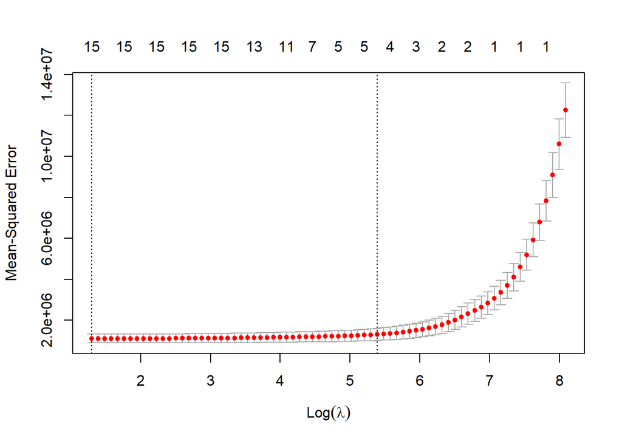

```r
# Fit Lasso model with cross-validation
lasso_model <- cv.glmnet(X_train, y_train, alpha = 1, nfolds = 10, lambda.min.ratio = 1e-4)

# Plot MSE as a function of log(lambda)
plot(lasso_model)
```

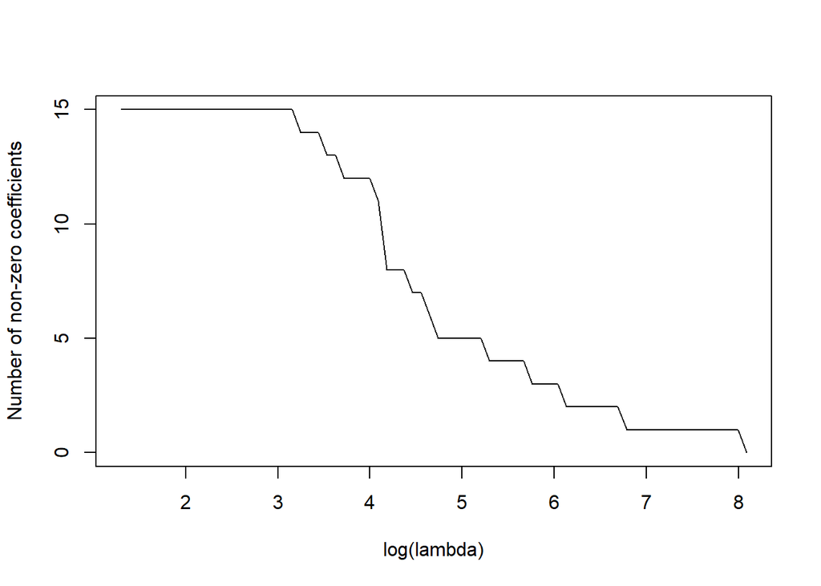

```r
# Plot number of non-zero coefficients as a function of log(lambda)
plot(log(lasso_model$lambda), lasso_model$glmnet.fit$df, type = "l", xlab = "log(lambda)", ylab = "Number of non-zero coefficients")
```

```r
# Get test predictions for optimal lambda
opt_lambda <- lasso_model$lambda.min
lasso_model_opt <- glmnet(X_train, y_train, alpha = 1, lambda = opt_lambda)
lasso_preds <- predict(lasso_model_opt, newx = X_test)
test_mse <- sqrt(mean((lasso_preds - y_test)^2))

# Report test error
cat(paste0("Test RMSE: ", test_mse, "\n"))
```

```
Test RMSE: 1315.05185935212
```

```r
coef(lasso_model_opt)
```

```
18 x 1 sparse Matrix of class "dgCMatrix"
                       s0
(Intercept) -731.99327047
Private     -532.85696906
Accept         1.26663501
Enroll         .
Top10perc     46.53688531
Top25perc    -13.34464132
F.Undergrad    0.02667861
P.Undergrad    0.03952648
Outstate      -0.05779551
Room.Board     0.16916873
Books          0.13075617
Personal       .
PhD           -6.87780046
Terminal      -3.80020795
S.F.Ratio     10.50121071
perc.alumni   -5.88127630
Expend         0.07523719
Grad.Rate     11.13474606
```

The lasso regression also performed worse than the full model, but it did effectively remove 2 highly insignificant variables - Enroll and Personal from the regression.

## Question-2:

Consider the **Boston** data. We want to predict **medv** from all other predictors, using the LASSO.

### Q2.a

Set up the LASSO and plot the trajectories of all coefficients. What are the last five variables to remain in the model?

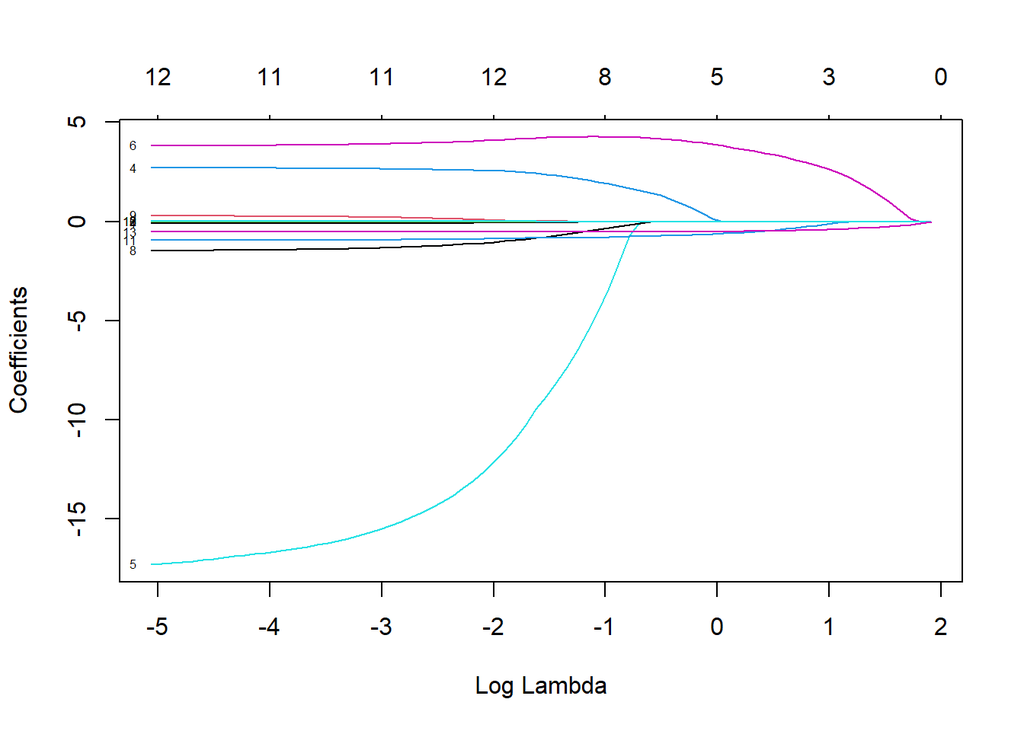

```r
data(Boston)
set.seed(123)

X <- model.matrix(medv ~., data = Boston)[,2:ncol(Boston)]
y  <- Boston[, 'medv']

# Fit LASSO model
lasso_mod <- cv.glmnet(X, y, alpha = 1, nfolds = 10)

# Plot coefficient trajectories
plot(lasso_mod$glmnet.fit, xvar = "lambda", label = TRUE)
```

```r
# Identify last five variables to remain in the model
lasso_mod_opt <- glmnet(X, y, alpha = 1, lambda = .8)
coef(lasso_mod_opt)
```

```
14 x 1 sparse Matrix of class "dgCMatrix"
                      s0
(Intercept) 14.591080859
crim         .
zn           .
indus        .
chas         0.661960730
nox          .
rm           4.023519352
age          .
dis          .
rad          .
tax          .
ptratio     -0.668680454
black        0.003612582
lstat       -0.500911909
```

The last 5 variables in the model are chas (near the Charles River), rm (Avg # of rooms), ptratio (student-teacher ratio), black (proportion of black people), and lstat.

### Q2.b

Find the 1SE value of $\lambda$, using 10-fold cross-validation. What is the cross validation estimate for the residual standard error?

```r
## Already did 10 fold CV above so get estimate from there
lambda.1se <- lasso_mod$lambda.1se

# compute cross-validation estimate of residual standard error
rse <- lasso_mod$cvm[which(lasso_mod$lambda == lambda.1se)]
cat(paste0("Lambda:",lambda.1se, "\n","RSE: ", rse, "\n"))
```

```
Lambda:0.500917541268124
RSE: 28.3814064219382
```

### Q2.c

Rescale all predictors so that their mean is zero and their standard deviation is 1. Then set up the LASSO and plot the trajectories of all coefficients.

What are the last five variables to remain in the model? Compare your answer to part a).

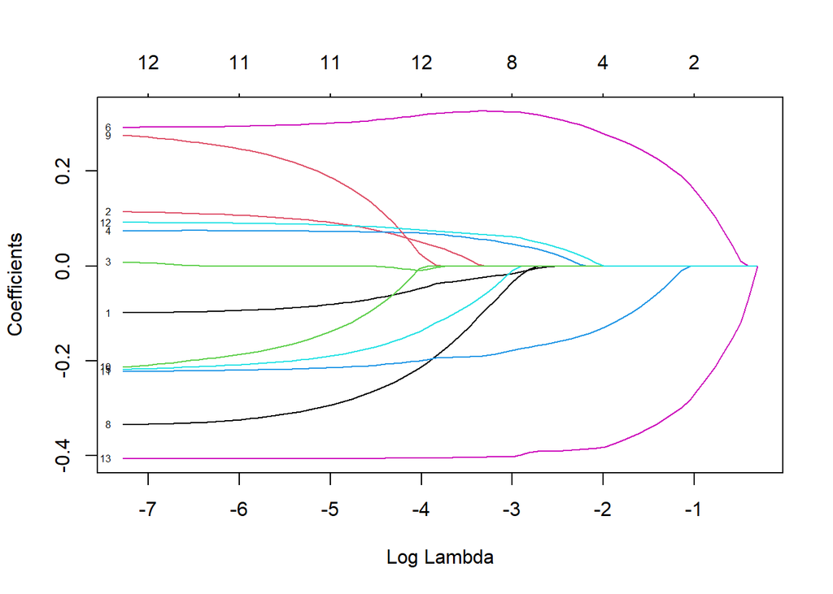

```r
# Fit LASSO model
X_s <- scale(X)
y_s <- scale(y)
lasso_mod_s <- cv.glmnet(X_s, y_s, alpha = 1, nfolds = 10)

# Plot coefficient trajectories
plot(lasso_mod_s$glmnet.fit, xvar = "lambda", label = TRUE)
```

```r
# Identify last five variables to remain in the model
lasso_mod_opt <- glmnet(X_s, y_s, alpha = 1, lambda = .09)
coef(lasso_mod_opt)
```

```
14 x 1 sparse Matrix of class "dgCMatrix"
                       s0
(Intercept) -1.718716e-16
crim         .
zn           .
indus        .
chas         1.576664e-02
nox          .
rm           3.055947e-01
age          .
dis          .
rad          .
tax          .
ptratio     -1.558143e-01
black        3.354449e-02
lstat       -3.885851e-01
```

The last 5 variables are the same here and in part A indicating agreement that these variables are the crucial ones for determining median home value.

### Q2.d

Find the 1SE value of $\lambda$, using 10-fold cross-validation. What is the cross validation estimate for the residual standard error now? Does rescaling lead to a better performing model?

```r
## Already did 10 fold CV above so get estimate from there
lambda.1se_s <- lasso_mod_s$lambda.1se

# compute cross-validation estimate of residual standard error
rse <- lasso_mod_s$cvm[which(lasso_mod_s$lambda == lambda.1se_s)]
cat(paste0("Lambda:",lambda.1se, "\n","RSE: ", rse, "\n"))
```

```
Lambda:0.500917541268124
RSE: 0.305067548626136
```

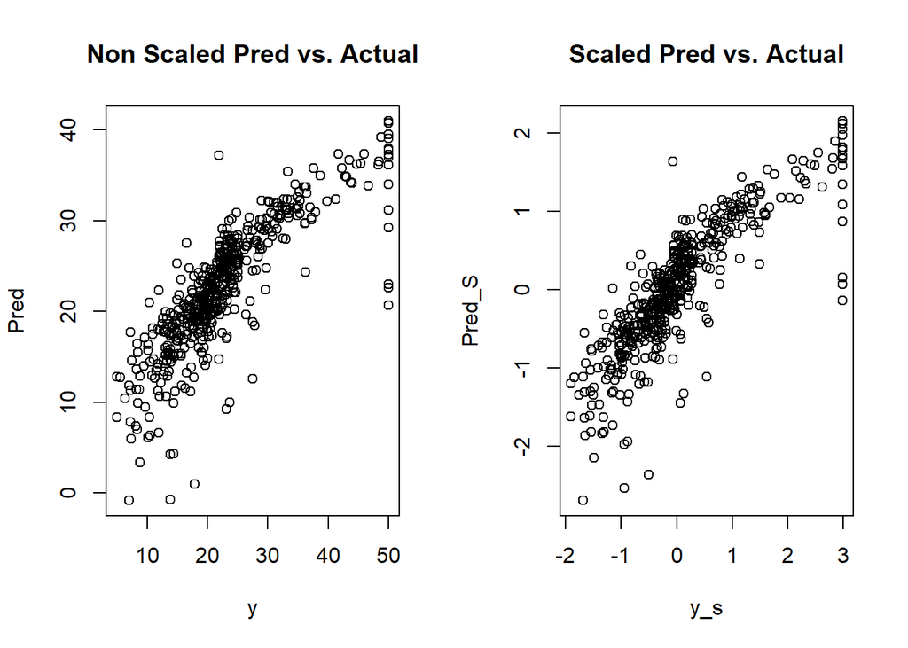

```r
par(mfrow = c(1,2))
plot(y, predict(lasso_mod, newx = X, lambda = lambda.1se), main = "Non Scaled Pred vs. Actual", ylab = "Pred")
plot(y_s, predict(lasso_mod_s, newx = X_s, lambda = lambda.1se_s), main = "Scaled Pred vs. Actual", ylab = "Pred_S")
```

Given the plots we can say that the models perform equally well, but the scaling does fit our predicted range into a smaller value range which can be helpful for data consistency across models.